# Time Series Forecast

https://en.wikipedia.org/wiki/Time_series In statistics, a time series is a series of data points indexed (or listed or graphed) in time order. Most commonly, a time series is a sequence taken at successive equally spaced points in time. Time series analysis comprises methods for analyzing time series data in order to extract meaningful statistics and other characteristics of the data. Time series forecasting is the use of a model to predict future values based on previously observed values.

I’ll produce a time series model using data from a bike sharing system, and use it to forecast future predictions. I have previously used this dataset with regression models.

The intention is to investigate the hypothesis of bike rentals being linked to weather conditions, using visualisations, and then conduct future forecasting.

http://archive.ics.uci.edu/ml/datasets/Bike+Sharing+Dataset “Bike sharing systems are new generation of traditional bike rentals where whole process from membership, rental and return back has become automatic. Through these systems, user is able to easily rent a bike from a particular position and return back at another position. Currently, there are about over 500 bike-sharing programs around the world which is composed of over 500 thousands bicycles. Today, there exists great interest in these systems due to their important role in traffic, environmental and health issues.”

Attribute Information: - instant: record index - dteday : date - season : season (1:springer, 2:summer, 3:fall, 4:winter) - yr : year (0: 2011, 1:2012) - mnth : month ( 1 to 12) - holiday : weather day is holiday or not (extracted from [Web Link]) - weekday : day of the week - workingday : if day is neither weekend nor holiday is 1, otherwise is 0. + weathersit : - 1: Clear, Few clouds, Partly cloudy, Partly cloudy - 2: Mist + Cloudy, Mist + Broken clouds, Mist + Few clouds, Mist - 3: Light Snow, Light Rain + Thunderstorm + Scattered clouds, Light Rain + Scattered clouds - 4: Heavy Rain + Ice Pallets + Thunderstorm + Mist, Snow + Fog - temp : Normalized temperature in Celsius. The values are derived via (t-t_min)/(t_max-t_min), t_min=-8, t_max=+39 (only in hourly scale) - atemp: Normalized feeling temperature in Celsius. The values are derived via (t-t_min)/(t_max-t_min), t_min=-16, t_max=+50 (only in hourly scale) - hum: Normalized humidity. The values are divided to 100 (max) - windspeed: Normalized wind speed. The values are divided to 67 (max) - casual: count of casual users - registered: count of registered users - cnt: count of total rental bikes including both casual and registered

| instant | dteday | season | yr | mnth | holiday | weekday | workingday | weathersit | temp | atemp | hum | windspeed | casual | registered | cnt |
| --- | --- | --- | --- | --- | --- | --- | --- | --- | --- | --- | --- | --- | --- | --- | --- |
| 726 | 2012-12-26 | 1 | 1 | 12 | 0 | 3 | 1 | 3 | 0.243333 | 0.220333 | 0.823333 | 0.316546 | 9 | 432 | 441 |
| 727 | 2012-12-27 | 1 | 1 | 12 | 0 | 4 | 1 | 2 | 0.254167 | 0.226642 | 0.652917 | 0.350133 | 247 | 1867 | 2114 |
| 728 | 2012-12-28 | 1 | 1 | 12 | 0 | 5 | 1 | 2 | 0.253333 | 0.255046 | 0.590000 | 0.155471 | 644 | 2451 | 3095 |
| 729 | 2012-12-29 | 1 | 1 | 12 | 0 | 6 | 0 | 2 | 0.253333 | 0.242400 | 0.752917 | 0.124383 | 159 | 1182 | 1341 |
| 730 | 2012-12-30 | 1 | 1 | 12 | 0 | 0 | 0 | 1 | 0.255833 | 0.231700 | 0.483333 | 0.350754 | 364 | 1432 | 1796 |
| 731 | 2012-12-31 | 1 | 1 | 12 | 0 | 1 | 1 | 2 | 0.215833 | 0.223487 | 0.577500 | 0.154846 | 439 | 2290 | 2729 |

So “dataset” is a data frame with 731 rows and 16 columns. Each row represent a single entry, one day, in which data is recorded about climate conditions, such as temperature and humidity, and the number of bike rentals which occur. This information is stored in the columns.

I’ll need to convert this data into a format useable with xts. The xts object has a time index and a matrix of corresponding observational data.

```r
#remove time data, remove unneeded columns, and encode dataset as xts object, ordering by date
data_xts <- as.xts(dataset[, c(-1:-9,-14,-15)], order.by = dataset$dteday)
head(data_xts)
```

```
               temp    atemp      hum windspeed  cnt
2011-01-01 0.344167 0.363625 0.805833 0.1604460  985
2011-01-02 0.363478 0.353739 0.696087 0.2485390  801
2011-01-03 0.196364 0.189405 0.437273 0.2483090 1349
2011-01-04 0.200000 0.212122 0.590435 0.1602960 1562
2011-01-05 0.226957 0.229270 0.436957 0.1869000 1600
2011-01-06 0.204348 0.233209 0.518261 0.0895652 1606
```

```r
#check start and end dates, and periodicity
periodicity(data_xts)
```

```
Daily periodicity from 2011-01-01 to 2012-12-31
```

My data is observed daily from Jan 1st, 2011 to Dec 31st, 2012, giving 2 years of observations.

I’ll plot the variables of my series on multiple plots.

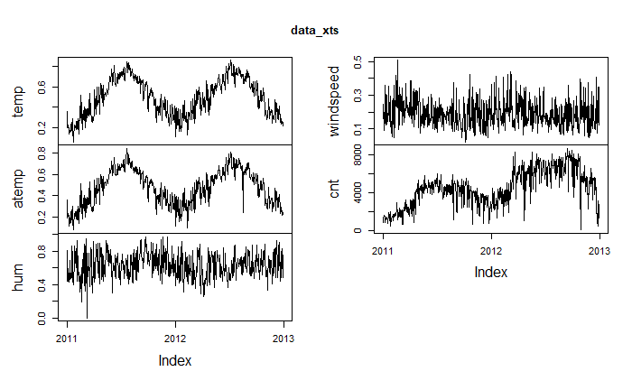

```r
#create multi-pane plot of all time series variables
plot.zoo(data_xts, plot.type = "multiple")
```

Predictably, weather conditions have seasonality, though the different attributes being measured do not neccessarily share changes.

By plotting all my variables on one plot, I can spot links easily.

```r
#create 2x1 plot frame
par(mfrow = c(2,1))
#plot non-count variables
plot.zoo(data_xts[,1:4], plot.type = "single", col=c("blue", "orange", "darkgreen","red"))
#plot count
plot.zoo(data_xts$cnt)
```

[output not shown]

Just by sight, I can tell there is seasonality in the count, peaking during the summer and ebbing in the winter. Deriving other links is harder; regression analysis, as used in my other notebooks, are a methodical approach to this.

///////////////////////

Next up, I’ll use ARIMA modelling to forecast future trends. This involves formalising aspects embedded in the data, and using those to calculate what the most likely observations will be in future.

This requires a stationary series. Observe the difference function of the count:

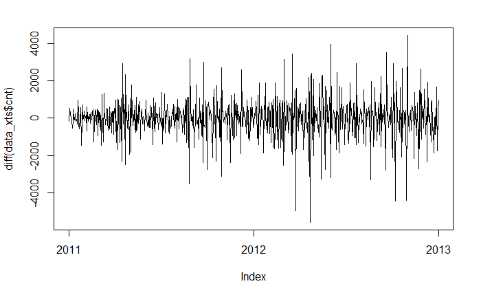

```r
plot.zoo(diff(data_xts$cnt))
```

This is evidently centred at 0, so I’ll use this for forecasting.

```
         ACF  PACF
  [1,]  0.85  0.85
  [2,]  0.78  0.22
  [3,]  0.75  0.17
  [4,]  0.74  0.17
  [5,]  0.74  0.17
  [6,]  0.75  0.17
  [7,]  0.74  0.05
  [8,]  0.73  0.06
  [9,]  0.71  0.03
 [10,]  0.70  0.05
 [11,]  0.69  0.00
 [12,]  0.69  0.03
 [13,]  0.69  0.05
 [14,]  0.71  0.12
```

[output cut: 351 more lines]

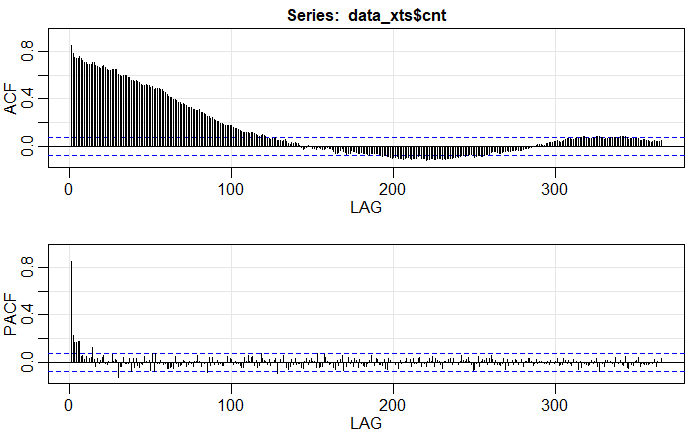

```r
#load astsa for time series modelling
library(astsa)
#
acf2(data_xts$cnt, max.lag = 365)
```